# Exercise2_TP1

Emily Schmidt

2022-10-23

```r
library(data.table) # Fast aggregation of large data sets and a fast file reader
library(lubridate) # Commute date-times
library(ggplot2) # Provides helpful commands to create complex plots from data in a data frame
library(reshape2) # Easily transform our data into whatever structure we may need
library(dplyr) # Data manipulation operations such as applying filter
library(tidyr) # Contains tools for changing the shape and hierarchy of a data set
library(caret) # Functions that attempt to streamline the process for creating predictive models
library(corrplot) # Graphical display of a correlation matrix, confidence interval or general matrix
library(lattice) # An implementation of Trellis graphics
library(RColorBrewer) # Tool to manage colors
```

## Problem 4.1 - Breakfast Cereals

### Preliminary data exploratory:

```r
setwd("C:\\Users\\emann\\GSEM Master\\Data Mining\\Homework 1") # Set directory
getwd() # Check the working directory
```

```
## [1] "C:/Users/emann/GSEM Master/Data Mining/Homework 1"
```

```r
Cereal <- fread("Cereals.csv", sep = ",", header = T) # Load your data, Cereals.csv
```

```r
dim(Cereal) # Get or set the dimension of the specified matrix, array or data frame
```

```
## [1] 77 16
```

```r
head(Cereal) # Display the first n rows present in the input data frame
```

```
##                         name mfr type calories protein fat sodium fiber carbo
## 1:                 100%_Bran   N    C       70       4   1    130  10.0   5.0
## 2:         100%_Natural_Bran   Q    C      120       3   5     15   2.0   8.0
## 3:                  All-Bran   K    C       70       4   1    260   9.0   7.0
## 4: All-Bran_with_Extra_Fiber   K    C       50       4   0    140  14.0   8.0
## 5:            Almond_Delight   R    C      110       2   2    200   1.0  14.0
## 6:   Apple_Cinnamon_Cheerios   G    C      110       2   2    180   1.5  10.5
##    sugars potass vitamins shelf weight cups   rating
## 1:      6    280       25     3      1 0.33 68.40297
## 2:      8    135        0     3      1 1.00 33.98368
## 3:      5    320       25     3      1 0.33 59.42551
## 4:      0    330       25     3      1 0.50 93.70491
## 5:      8     NA       25     3      1 0.75 34.38484
## 6:     10     70       25     1      1 0.75 29.50954
```

```r
View(Cereal) # Invoke a spreadsheet-style data viewer within RStudio
summary(Cereal) # Produce result summaries of the results of various model fitting functions
```

```
##      name               mfr                type              calories
##  Length:77          Length:77          Length:77          Min.   : 50.0
##  Class :character   Class :character   Class :character   1st Qu.:100.0
##  Mode  :character   Mode  :character   Mode  :character   Median :110.0
##                                                           Mean   :106.9
##                                                           3rd Qu.:110.0
##                                                           Max.   :160.0
##
##     protein           fat            sodium          fiber
##  Min.   :1.000   Min.   :0.000   Min.   :  0.0   Min.   : 0.000
##  1st Qu.:2.000   1st Qu.:0.000   1st Qu.:130.0   1st Qu.: 1.000
##  Median :3.000   Median :1.000   Median :180.0   Median : 2.000
##  Mean   :2.545   Mean   :1.013   Mean   :159.7   Mean   : 2.152
##  3rd Qu.:3.000   3rd Qu.:2.000   3rd Qu.:210.0   3rd Qu.: 3.000
##  Max.   :6.000   Max.   :5.000   Max.   :320.0   Max.   :14.000
##
##      carbo          sugars           potass          vitamins
##  Min.   : 5.0   Min.   : 0.000   Min.   : 15.00   Min.   :  0.00
##  1st Qu.:12.0   1st Qu.: 3.000   1st Qu.: 42.50   1st Qu.: 25.00
##  Median :14.5   Median : 7.000   Median : 90.00   Median : 25.00
##  Mean   :14.8   Mean   : 7.026   Mean   : 98.67   Mean   : 28.25
##  3rd Qu.:17.0   3rd Qu.:11.000   3rd Qu.:120.00   3rd Qu.: 25.00
##  Max.   :23.0   Max.   :15.000   Max.   :330.00   Max.   :100.00
##  NA's   :1      NA's   :1        NA's   :2
##      shelf           weight          cups           rating
##  Min.   :1.000   Min.   :0.50   Min.   :0.250   Min.   :18.04
##  1st Qu.:1.000   1st Qu.:1.00   1st Qu.:0.670   1st Qu.:33.17
##  Median :2.000   Median :1.00   Median :0.750   Median :40.40
##  Mean   :2.208   Mean   :1.03   Mean   :0.821   Mean   :42.67
##  3rd Qu.:3.000   3rd Qu.:1.00   3rd Qu.:1.000   3rd Qu.:50.83
##  Max.   :3.000   Max.   :1.50   Max.   :1.500   Max.   :93.70
##
```

```r
str(Cereal) # Compactly displaying the internal structure of a R object
```

```
## Classes 'data.table' and 'data.frame':   77 obs. of  16 variables:
##  $ name    : chr  "100%_Bran" "100%_Natural_Bran" "All-Bran" "All-Bran_with_Extra_Fiber" ...
##  $ mfr     : chr  "N" "Q" "K" "K" ...
##  $ type    : chr  "C" "C" "C" "C" ...
##  $ calories: int  70 120 70 50 110 110 110 130 90 90 ...
##  $ protein : int  4 3 4 4 2 2 2 3 2 3 ...
##  $ fat     : int  1 5 1 0 2 2 0 2 1 0 ...
##  $ sodium  : int  130 15 260 140 200 180 125 210 200 210 ...
##  $ fiber   : num  10 2 9 14 1 1.5 1 2 4 5 ...
##  $ carbo   : num  5 8 7 8 14 10.5 11 18 15 13 ...
##  $ sugars  : int  6 8 5 0 8 10 14 8 6 5 ...
##  $ potass  : int  280 135 320 330 NA 70 30 100 125 190 ...
##  $ vitamins: int  25 0 25 25 25 25 25 25 25 25 ...
##  $ shelf   : int  3 3 3 3 3 1 2 3 1 3 ...
##  $ weight  : num  1 1 1 1 1 1 1 1.33 1 1 ...
##  $ cups    : num  0.33 1 0.33 0.5 0.75 0.75 1 0.75 0.67 0.67 ...
##  $ rating  : num  68.4 34 59.4 93.7 34.4 ...
##  - attr(*, ".internal.selfref")=<externalptr>
```

```r
 which(is.na(Cereal)) # Function returns the positions with missing values
```

```
## [1] 674 751 775 791
```

```r
sum(is.na(Cereal))  # Sum the total amount of missing values in the data set
```

```
## [1] 4
```

```r
Cereals <- na.omit(Cereal) # Remove the missing values
summary(Cereals) # Call the data set to ensure that missing values are removed
```

```
##      name               mfr                type              calories
##  Length:74          Length:74          Length:74          Min.   : 50
##  Class :character   Class :character   Class :character   1st Qu.:100
##  Mode  :character   Mode  :character   Mode  :character   Median :110
##                                                           Mean   :107
##                                                           3rd Qu.:110
##                                                           Max.   :160
##     protein           fat        sodium          fiber            carbo
##  Min.   :1.000   Min.   :0   Min.   :  0.0   Min.   : 0.000   Min.   : 5.00
##  1st Qu.:2.000   1st Qu.:0   1st Qu.:135.0   1st Qu.: 0.250   1st Qu.:12.00
##  Median :2.500   Median :1   Median :180.0   Median : 2.000   Median :14.50
##  Mean   :2.514   Mean   :1   Mean   :162.4   Mean   : 2.176   Mean   :14.73
##  3rd Qu.:3.000   3rd Qu.:1   3rd Qu.:217.5   3rd Qu.: 3.000   3rd Qu.:17.00
##  Max.   :6.000   Max.   :5   Max.   :320.0   Max.   :14.000   Max.   :23.00
##      sugars           potass          vitamins          shelf
##  Min.   : 0.000   Min.   : 15.00   Min.   :  0.00   Min.   :1.000
##  1st Qu.: 3.000   1st Qu.: 41.25   1st Qu.: 25.00   1st Qu.:1.250
##  Median : 7.000   Median : 90.00   Median : 25.00   Median :2.000
##  Mean   : 7.108   Mean   : 98.51   Mean   : 29.05   Mean   :2.216
##  3rd Qu.:11.000   3rd Qu.:120.00   3rd Qu.: 25.00   3rd Qu.:3.000
##  Max.   :15.000   Max.   :330.00   Max.   :100.00   Max.   :3.000
##      weight           cups            rating
##  Min.   :0.500   Min.   :0.2500   Min.   :18.04
##  1st Qu.:1.000   1st Qu.:0.6700   1st Qu.:32.45
##  Median :1.000   Median :0.7500   Median :40.25
##  Mean   :1.031   Mean   :0.8216   Mean   :42.37
##  3rd Qu.:1.000   3rd Qu.:1.0000   3rd Qu.:50.52
##  Max.   :1.500   Max.   :1.5000   Max.   :93.70
```

One of the most important parts of analyzing your data is to conduct a preliminary exploratory review. The following points outline high-level conclusions:  
- There are 77 observations and 16 variables within the raw data set  
- There is information on rating, shelf height, cereal name, and cereal features - When calling summary() and str(), we notice there are missing values and various types of variables (chr, int, and num)  
- Diving deeper into the missing values, there are 4 NAs. Therefore, we omit.

**A**. *Which variables are quantitative/numerical? Which are ordinal? Which are nominal?*

Quantitative variables:  
- calories, protein, fat, sodium, fiber, carbo, sugars, potass, vitamins, weight, cups, and rating

Categorical variables (N/O):  
- N: name, mfr, and type  
- O: shelf

**B**. *Compute the mean, median, min, max, and standard deviation for each of the quantitative variables.*

```r
# Takes a list/vector/data frame as an input and gives an output in a vector or matrix for a defined function (ex. mean)
sapply(Cereals[,c(4:12, 14:16)], mean, na.rm = T)
```

```
##    calories     protein         fat      sodium       fiber       carbo
## 107.0270270   2.5135135   1.0000000 162.3648649   2.1756757  14.7297297
##      sugars      potass    vitamins      weight        cups      rating
##   7.1081081  98.5135135  29.0540541   1.0308108   0.8216216  42.3717869
```

```r
sapply(Cereals[,c(4:12, 14:16)], median, na.rm = T)
```

```
##  calories   protein       fat    sodium     fiber     carbo    sugars    potass
## 110.00000   2.50000   1.00000 180.00000   2.00000  14.50000   7.00000  90.00000
##  vitamins    weight      cups    rating
##  25.00000   1.00000   0.75000  40.25309
```

```r
sapply(Cereals[,c(4:12, 14:16)], min, na.rm = T)
```

```
## calories  protein      fat   sodium    fiber    carbo   sugars   potass
## 50.00000  1.00000  0.00000  0.00000  0.00000  5.00000  0.00000 15.00000
## vitamins   weight     cups   rating
##  0.00000  0.50000  0.25000 18.04285
```

```r
sapply(Cereals[,c(4:12, 14:16)], max, na.rm = T)
```

```
##  calories   protein       fat    sodium     fiber     carbo    sugars    potass
## 160.00000   6.00000   5.00000 320.00000  14.00000  23.00000  15.00000 330.00000
##  vitamins    weight      cups    rating
## 100.00000   1.50000   1.50000  93.70491
```

```r
sapply(Cereals[,c(4:12, 14:16)], sd, na.rm = T)
```

```
##   calories    protein        fat     sodium      fiber      carbo     sugars
## 19.8438928  1.0758016  1.0068260 82.7697871  2.4233912  3.8916746  4.3591113
##     potass   vitamins     weight       cups     rating
## 70.8786815 22.2943521  0.1534155  0.2357153 14.0337125
```

```r
# Better way to show the summary statistics in an organized table
# Create a summary statistics table to show metrics, ensuring that missing values are not included
CSUM <- data.frame(mean = sapply(Cereals[,c(4:12, 14:16)], mean,na.rm = T)
                ,median = sapply(Cereals[,c(4:12, 14:16)], median,na.rm = T)
                ,min = sapply(Cereals[,c(4:12, 14:16)], min,na.rm = T)
                ,max = sapply(Cereals[,c(4:12, 14:16)], max,na.rm = T)
                ,sd = sapply(Cereals[,c(4:12, 14:16)], sd,na.rm = T))
colnames(CSUM) = c("Mean","Median","Min","Max","Standard Deviation")
CSUM
```

```
##                 Mean    Median      Min       Max Standard Deviation
## calories 107.0270270 110.00000 50.00000 160.00000         19.8438928
## protein    2.5135135   2.50000  1.00000   6.00000          1.0758016
## fat        1.0000000   1.00000  0.00000   5.00000          1.0068260
## sodium   162.3648649 180.00000  0.00000 320.00000         82.7697871
## fiber      2.1756757   2.00000  0.00000  14.00000          2.4233912
## carbo     14.7297297  14.50000  5.00000  23.00000          3.8916746
## sugars     7.1081081   7.00000  0.00000  15.00000          4.3591113
## potass    98.5135135  90.00000 15.00000 330.00000         70.8786815
## vitamins  29.0540541  25.00000  0.00000 100.00000         22.2943521
## weight     1.0308108   1.00000  0.50000   1.50000          0.1534155
## cups       0.8216216   0.75000  0.25000   1.50000          0.2357153
## rating    42.3717869  40.25309 18.04285  93.70491         14.0337125
```

Within the 12 quantitative variables, the mean, median, min, max, and standard deviation all differ. This is in part due to their scaling. For example, sodium and weight are not comparable unless normalized since you have a scale ranging from 0 to 320 while the other weight is 0.5 to 1.5. Another observation is the standard deviation. Three variables have a much more dispersed in relation to the mean than other variables.

**C**. *Use R to plot a histogram for each of the quantitative variables. Based on the histograms and summary statistics, answer the following questions:*

```r
Cereals %>% gather() %>% head() # Reshaping the data which means it collects a set of column names and places them into a single “key” column
```

```
##    key                     value
## 1 name                 100%_Bran
## 2 name         100%_Natural_Bran
## 3 name                  All-Bran
## 4 name All-Bran_with_Extra_Fiber
## 5 name   Apple_Cinnamon_Cheerios
## 6 name               Apple_Jacks
```

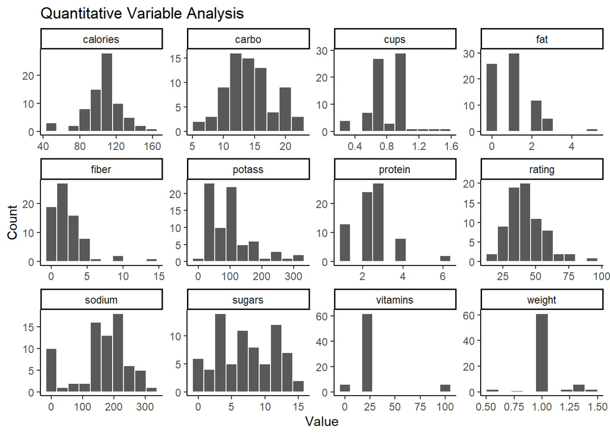

```r
q_data <- na.omit(Cereals[,c(4:12, 14:16)]) # Removes the missing variables from the quantitative columns

ggplot(gather(data = q_data),aes(value)) +
  geom_histogram(bins = 10, color = "white") + # Creates bin sizing and sets the lines as white
  facet_wrap(~key,scales = "free") + # Converting the graphs into panels
  ggtitle("Quantitative Variable Analysis") + # Title name
  ylab("Count") + xlab("Value") + # Label names
  theme_classic() # A classic theme, with x and y axis lines and no grid lines
```

**i.** *Which variables have the largest variability?* Out of the 12 variables, sodium and potass have the largest variability as they range from 0 to 300+. Another two variables that seem to fall under this category was vitamins and calories due to another analysis of reviewing their var().

**ii.** *Which variables seem skewed?* Visually, one will notice that a majority of the histograms are skewed right, meaning that they are positively skewed. On the other hand, there are several variables that are negative/skewed left (cups, sodium, and, calories). The variables that seem to be skewed the most are fiber and fat.

**iii.** *Are there any values that seem extreme?* Within the 12 charts, I believe there are several outliers that can be identified by visually reviewing each variable. For instance, fiber, protein, weight, and vitamins all have values that are distant from other data points. If we were to calculate the outliers position compared to the mean, one might also say that the following charts may have outliers present: calories, cups, and sodium.

**D**. *Use R to plot a side-by-side boxplot comparing the calories in hot vs cold cereals. What does this plot show us?*

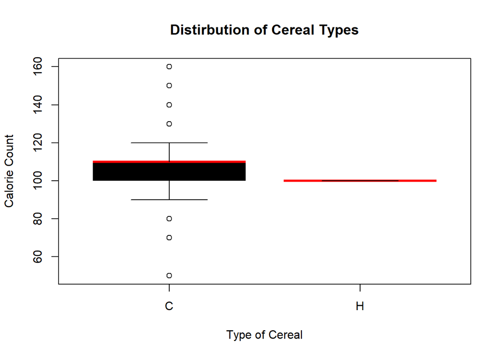

```r
#cal_type.box <- ggplot(data = Cereals,aes(x = type, y = calories, fill = type)) + # Call the ggplot to begin creating the visualization
  #geom_boxplot() + # Type of graph generated
  #ggtitle("Distirbution of Cereal Types") + # Title name
  #ylab("Calorie Count") + xlab("Type of Cereal")  + # Label names
  #stat_boxplot(geom = 'errorbar', linetype=1, width=0.5) +  # Allows you to see the outliers beyond the minimum and maximum
  #stat_summary(fun = "mean") + # fun.y could also equal min or max to see their position
  #theme_classic() # Clean background behind the graph

#cal_type.box

# Create a box plot analyzing the calories vs type with graph characteristics
boxplot(calories~type, data = Cereals, main = "Distirbution of Cereal Types", # Title names
        xlab = "Type of Cereal",ylab = "Calorie Count", # Label names
        col = "black",medcol = "red",boxlty = 0,border = "black", # Changing the style of the box plot
        whisklty = 1,staplelwd = 1,outpch = 1,outcex = 1,outcol = "black") # Changing the style of the box plot
```

**E**. *Use R to plot a side-by-side boxplot of consumer rating as a function of the shelf height. If we were to predict consumer rating from shelf height, does it appear that we need to keep all three categories of shelf height?*

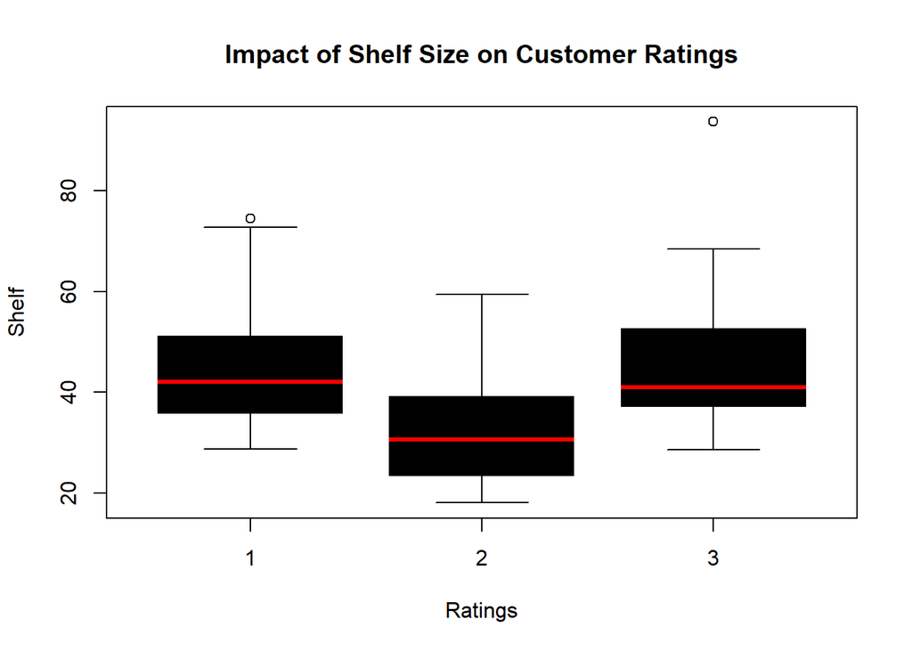

```r
# Create a box plot analyzing the ratings vs shelf height with graph characteristics
boxplot(rating~shelf, data = Cereals, main = "Impact of Shelf Size on Customer Ratings", # Title Name
        xlab = "Ratings", ylab = "Shelf", # Label names
        col = "black",medcol = "red", boxlty = 0,border = "black", # Changing the style of the box plot
        whisklty = 1,staplelwd = 1,outpch = 1,outcex = 1,outcol = "black") # Changing the style of the box plot
```

My suggestion would be to investigate the data further to make such a conclusion. There is no statistical evidence to claim which shelf we should remove or keep. If we were to just visually look at the box plots though, I would assume that the second shelf would be removed since its mean rating is lower than 1 and 3.

**F.** *Compute the correlation table for the quantitative variable (function cor()). In addition, generate a matrix plot for these variables (function plot(data)).*

```r
q_data <- na.omit(Cereals[,c(4:12, 14:16)]) # Removes the missing variables from the quantitative columns

cormat <- round(cor(q_data),2) # Round the correlation coefficient to two decimal places
head(cormat) # Display the first n rows present in the input data
```

```
##          calories protein   fat sodium fiber carbo sugars potass vitamins
## calories     1.00    0.03  0.51   0.30 -0.30  0.27   0.57  -0.07     0.26
## protein      0.03    1.00  0.20   0.01  0.51 -0.04  -0.29   0.58     0.05
## fat          0.51    0.20  1.00   0.00  0.01 -0.28   0.29   0.20    -0.03
## sodium       0.30    0.01  0.00   1.00 -0.07  0.33   0.04  -0.04     0.33
## fiber       -0.30    0.51  0.01  -0.07  1.00 -0.38  -0.15   0.91    -0.04
## carbo        0.27   -0.04 -0.28   0.33 -0.38  1.00  -0.45  -0.37     0.25
##          weight  cups rating
## calories   0.70  0.09  -0.69
## protein    0.23 -0.24   0.47
## fat        0.22 -0.16  -0.41
## sodium     0.31  0.12  -0.38
## fiber      0.25 -0.51   0.60
## carbo      0.14  0.36   0.06
```

```r
melted_cormat <- melt(cormat) # One way to reshape and elongate the data frame
head(melted_cormat) # Display the first n rows present in the input data
```

```
##       Var1     Var2 value
## 1 calories calories  1.00
## 2  protein calories  0.03
## 3      fat calories  0.51
## 4   sodium calories  0.30
## 5    fiber calories -0.30
## 6    carbo calories  0.27
```

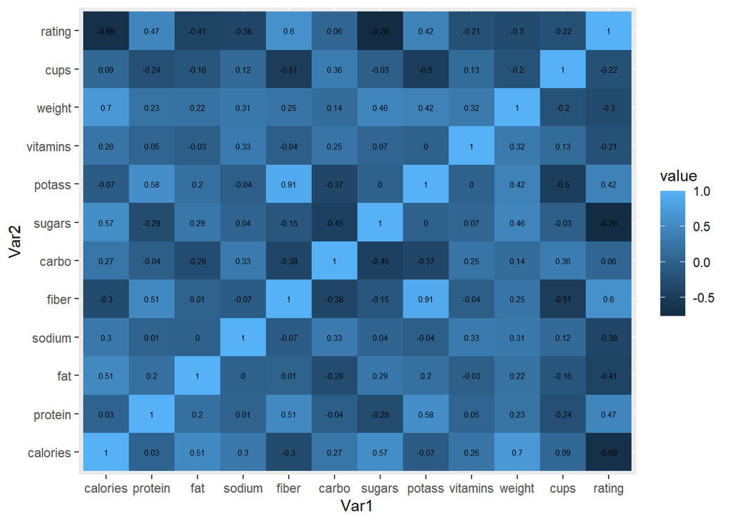

```r
# Create correlation matrix (tiles) with the rounded correlation coefficient
ggplot(data = melted_cormat, aes(x = Var1, y = Var2, fill = value)) +
  geom_tile() +
  geom_text(aes(Var2, Var1, label = value), color = "black", size = 2)
```

```r
# Get upper triangle of the correlation matrix
  get_upper_tri <- function(cormat){
    cormat[lower.tri(cormat)]<- NA
    return(cormat)
  }

# Rename the correlation coefficient value
upper_tri <- get_upper_tri(cormat)
upper_tri
```

```
##          calories protein  fat sodium fiber carbo sugars potass vitamins weight
## calories        1    0.03 0.51   0.30 -0.30  0.27   0.57  -0.07     0.26   0.70
## protein        NA    1.00 0.20   0.01  0.51 -0.04  -0.29   0.58     0.05   0.23
## fat            NA      NA 1.00   0.00  0.01 -0.28   0.29   0.20    -0.03   0.22
## sodium         NA      NA   NA   1.00 -0.07  0.33   0.04  -0.04     0.33   0.31
## fiber          NA      NA   NA     NA  1.00 -0.38  -0.15   0.91    -0.04   0.25
## carbo          NA      NA   NA     NA    NA  1.00  -0.45  -0.37     0.25   0.14
## sugars         NA      NA   NA     NA    NA    NA   1.00   0.00     0.07   0.46
## potass         NA      NA   NA     NA    NA    NA     NA   1.00     0.00   0.42
## vitamins       NA      NA   NA     NA    NA    NA     NA     NA     1.00   0.32
## weight         NA      NA   NA     NA    NA    NA     NA     NA       NA   1.00
## cups           NA      NA   NA     NA    NA    NA     NA     NA       NA     NA
## rating         NA      NA   NA     NA    NA    NA     NA     NA       NA     NA
##           cups rating
## calories  0.09  -0.69
## protein  -0.24   0.47
## fat      -0.16  -0.41
## sodium    0.12  -0.38
## fiber    -0.51   0.60
## carbo     0.36   0.06
## sugars   -0.03  -0.76
## potass   -0.50   0.42
## vitamins  0.13  -0.21
## weight   -0.20  -0.30
## cups      1.00  -0.22
## rating      NA   1.00
```

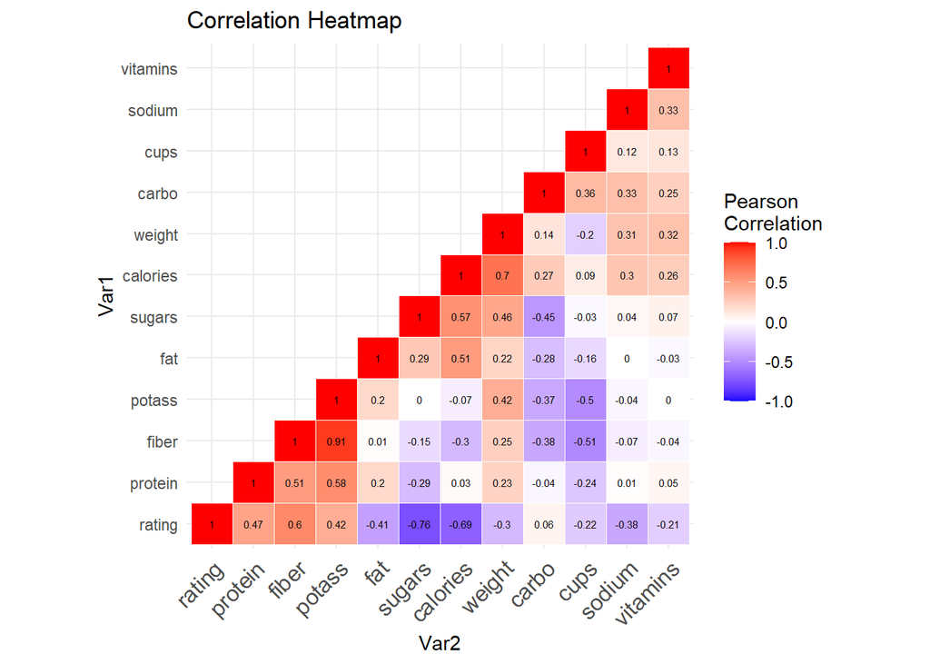

```r
# Use correlation between variables as distance
reorder_cormat <- function(cormat){
dd <- as.dist((1-cormat)/2)
hc <- hclust(dd)
cormat <-cormat[hc$order, hc$order]
}

# Reorder the correlation matrix
cormat <- reorder_cormat(cormat)
upper_tri <- get_upper_tri(cormat)

# Melt the correlation matrix
melted_cormat <- melt(upper_tri, na.rm = TRUE)

# Create a ggheatmap with multiple characteristics
ggheatmap <- ggplot(melted_cormat, aes(Var2, Var1, fill = value)) +
  geom_tile(color = "white") +
  scale_fill_gradient2(low = "blue", high = "red", mid = "white", midpoint = 0, limit = c(-1,1), space = "Lab", name="Pearson\nCorrelation") +
  ggtitle("Correlation Heatmap") + # Title name
  theme_minimal() + # Minimal theme, keeps in the lines
  theme(axis.text.x = element_text(angle = 45, vjust = 1, size = 12, hjust = 1)) +
  coord_fixed() +
  geom_text(aes(Var2, Var1, label = value), color = "black", size = 2)

# Print the heat map
print(ggheatmap)
```

**i.** *Which pair of variables is the most strongly correlated?*  
There are three correlations that stick out in the matrix below:  
- fiber and potass at a correlation of 0.91  
- sugar and ratings have a negative correlation at -0.76  
- calories and weight have a positive correlation at 0.70  
All other correlations do not have as strong of a relation between one another and not worth mentioning at this point in the analysis.

**ii.** *How can we reduce the number of variables based on these correlations?*  
Based on our quantitative variables, we can utilize the method of PCA. This will allow us to reduce the number of variables while making the maximum use of their unique contributions to the overall variation because variation in one variable is duplicated by similar variation in the other variable. In order to perform this method, one needs to find a linear combination of the two variables that contains most of the information so that the new variable can replace the two original ones. - Source: Data Mining textbook

**iii**. *How would the correlations change if we normalized the data first?*

```r
pcs.cor <- prcomp(na.omit(Cereals[,-c(1:3)])) # Compute PCs data set

summary(pcs.cor) # Review the summary of those values
```

```
## Importance of components:
##                            PC1     PC2      PC3      PC4     PC5     PC6
## Standard deviation     83.7641 70.9143 22.64375 19.18148 8.42323 2.09167
## Proportion of Variance  0.5395  0.3867  0.03943  0.02829 0.00546 0.00034
## Cumulative Proportion   0.5395  0.9262  0.96560  0.99389 0.99935 0.99968
##                            PC7     PC8     PC9    PC10   PC11    PC12      PC13
## Standard deviation     1.69942 0.77963 0.65783 0.37043 0.1864 0.06302 5.334e-08
## Proportion of Variance 0.00022 0.00005 0.00003 0.00001 0.0000 0.00000 0.000e+00
## Cumulative Proportion  0.99991 0.99995 0.99999 1.00000 1.0000 1.00000 1.000e+00
```

```r
# 96% of the total variation associated with all 13 of the original variables is captured in the first three components

pcs.cor$rot[,1:5]
```

```
##                    PC1           PC2           PC3           PC4          PC5
## calories  0.0779841812  0.0093115874 -0.6292057595 -0.6010214629  0.454958508
## protein  -0.0007567806 -0.0088010282 -0.0010261160  0.0031999095  0.056175970
## fat      -0.0001017834 -0.0026991522 -0.0161957859 -0.0252622140 -0.016098458
## sodium    0.9802145422 -0.1408957901  0.1359018583 -0.0009680741  0.013948118
## fiber    -0.0054127550 -0.0306807512  0.0181910456  0.0204721894  0.013605026
## carbo     0.0172462607  0.0167832981 -0.0173699816  0.0259482087  0.349266966
## sugars    0.0029888631  0.0002534853 -0.0977049979 -0.1154809105 -0.299066459
## potass   -0.1349000039 -0.9865619808 -0.0367824989 -0.0421757390 -0.047150529
## vitamins  0.0942933187 -0.0167288404 -0.6919777623  0.7141179984 -0.037008623
## shelf    -0.0015414195 -0.0043603994 -0.0124888415  0.0056471836 -0.007876459
## weight    0.0005120017 -0.0009992138 -0.0038059565 -0.0025464145  0.003022113
## cups      0.0005101111  0.0015910125 -0.0006943214  0.0009853800  0.002148458
## rating   -0.0752962922 -0.0717421528  0.3079471212  0.3345338994  0.757708025
```

```r
pcs.cor <- prcomp(na.omit(Cereals[,-c(1:3)]), scale. = T) # Compute PCs data set
summary(pcs.cor)
```

```
## Importance of components:
##                           PC1    PC2    PC3     PC4    PC5     PC6     PC7
## Standard deviation     1.9062 1.7743 1.3818 1.00969 0.9947 0.84974 0.81946
## Proportion of Variance 0.2795 0.2422 0.1469 0.07842 0.0761 0.05554 0.05166
## Cumulative Proportion  0.2795 0.5217 0.6685 0.74696 0.8231 0.87861 0.93026
##                            PC8     PC9    PC10    PC11    PC12      PC13
## Standard deviation     0.64515 0.56192 0.30301 0.25194 0.13897 1.499e-08
## Proportion of Variance 0.03202 0.02429 0.00706 0.00488 0.00149 0.000e+00
## Cumulative Proportion  0.96228 0.98657 0.99363 0.99851 1.00000 1.000e+00
```

```r
pcs.cor$rot[,1:5]
```

```
##                  PC1        PC2          PC3         PC4         PC5
## calories  0.29954236  0.3931479 -0.114857453  0.20435870  0.20389885
## protein  -0.30735632  0.1653233 -0.277281953  0.30074318  0.31974897
## fat       0.03991542  0.3457243  0.204890102  0.18683311  0.58689327
## sodium    0.18339651  0.1372205 -0.389431009  0.12033726 -0.33836424
## fiber    -0.45349036  0.1798119 -0.069766079  0.03917361 -0.25511906
## carbo     0.19244902 -0.1494483 -0.562452458  0.08783547  0.18274252
## sugars    0.22806849  0.3514345  0.355405174 -0.02270716 -0.31487243
## potass   -0.40196429  0.3005442 -0.067620183  0.09087843 -0.14836048
## vitamins  0.11598020  0.1729092 -0.387858660 -0.60411064 -0.04928672
## shelf    -0.17126336  0.2650503  0.001531036 -0.63887859  0.32910135
## weight    0.05029930  0.4503085 -0.247138314  0.15342874 -0.22128334
## cups      0.29463553 -0.2122479 -0.139999705  0.04748909  0.12081645
## rating   -0.43837841 -0.2515389 -0.181842433  0.03831622  0.05758420
```

```r
# Now we find that we need 7 principal components to account for more than 90% of the total variability. The first 2 principal components account  for only 52% of the total variability, and thus reducing the number of variables to two would mean losing a lot of information.

normCereal = preProcess(Cereals[,4:16],method = c("center","scale"),na.rm = T) # Estimates the required parameters for each operation and predict
NormcmCereal = predict(normCereal,Cereals[,4:16]) # predict the values based on the input data

cmCereal2 = cor(NormcmCereal,use = "complete.obs")
round(cmCereal2,2) # Round function to two decimals
```

```
##          calories protein   fat sodium fiber carbo sugars potass vitamins shelf
## calories     1.00    0.03  0.51   0.30 -0.30  0.27   0.57  -0.07     0.26  0.09
## protein      0.03    1.00  0.20   0.01  0.51 -0.04  -0.29   0.58     0.05  0.20
## fat          0.51    0.20  1.00   0.00  0.01 -0.28   0.29   0.20    -0.03  0.28
## sodium       0.30    0.01  0.00   1.00 -0.07  0.33   0.04  -0.04     0.33 -0.12
## fiber       -0.30    0.51  0.01  -0.07  1.00 -0.38  -0.15   0.91    -0.04  0.31
## carbo        0.27   -0.04 -0.28   0.33 -0.38  1.00  -0.45  -0.37     0.25 -0.19
## sugars       0.57   -0.29  0.29   0.04 -0.15 -0.45   1.00   0.00     0.07  0.06
## potass      -0.07    0.58  0.20  -0.04  0.91 -0.37   0.00   1.00     0.00  0.39
## vitamins     0.26    0.05 -0.03   0.33 -0.04  0.25   0.07   0.00     1.00  0.28
## shelf        0.09    0.20  0.28  -0.12  0.31 -0.19   0.06   0.39     0.28  1.00
## weight       0.70    0.23  0.22   0.31  0.25  0.14   0.46   0.42     0.32  0.19
## cups         0.09   -0.24 -0.16   0.12 -0.51  0.36  -0.03  -0.50     0.13 -0.35
## rating      -0.69    0.47 -0.41  -0.38  0.60  0.06  -0.76   0.42    -0.21  0.05
##          weight  cups rating
## calories   0.70  0.09  -0.69
## protein    0.23 -0.24   0.47
## fat        0.22 -0.16  -0.41
## sodium     0.31  0.12  -0.38
## fiber      0.25 -0.51   0.60
## carbo      0.14  0.36   0.06
## sugars     0.46 -0.03  -0.76
## potass     0.42 -0.50   0.42
## vitamins   0.32  0.13  -0.21
## shelf      0.19 -0.35   0.05
## weight     1.00 -0.20  -0.30
## cups      -0.20  1.00  -0.22
## rating    -0.30 -0.22   1.00
```

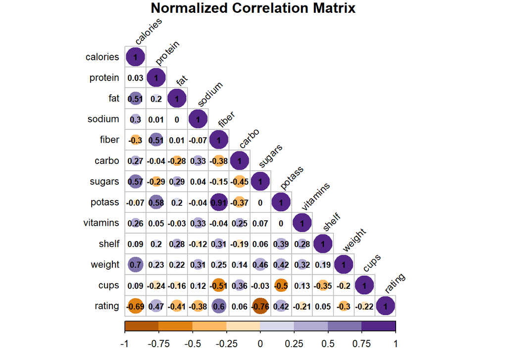

```r
corrplot(cmCereal2, type = "lower", main = "Normalized Correlation Matrix", mar=c(0,0,1,0), tl.cex=0.8, tl.col="black", tl.srt=45, addCoef.col = "black", number.cex = 0.7, col=brewer.pal(n=8, name="PuOr")) # brewer.pal came from the library RColorBrewer
```